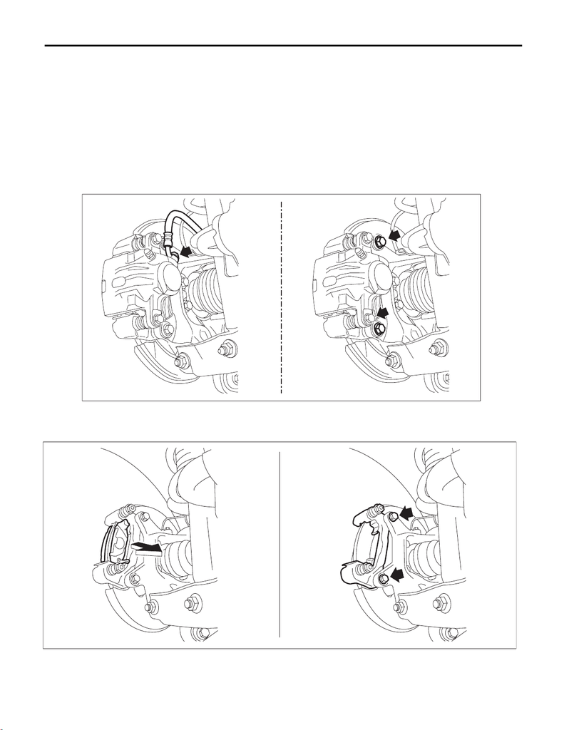

BR-43

Rear Disc Brake Assembly

BRAKE

7. Rear Disc Brake Assembly

A: REMOVAL

1. EXCEPT FOR STI MODEL

1) Lift up the vehicle, and then remove the rear wheels.

2) Remove the union bolt and the caliper bolt, and remove the caliper body assembly.

CAUTION:

• Do not allow brake fluid to come in contact with the painted surface of the vehicle body. If it does,

wash off with water and wipe away completely.

• Prepare a container to catch grease or oil, etc. If any grease or oil spills, wipe it off and clean im-

mediately to prevent from penetrating into floor or flowing outside.

3) Remove the support - rear disc brake.

(1) Remove the pad - disc brake rear.

(2) Remove the mounting bolts, and then remove the support - rear disc brake.

BR-01282

BR-01283

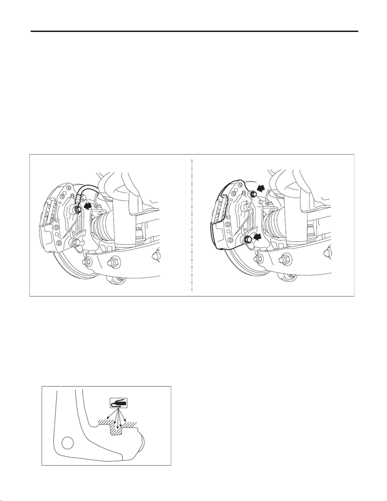

BR-44

Rear Disc Brake Assembly

BRAKE

2. STI MODEL

CAUTION:

Do not allow brake fluid to come in contact with the painted surface of the vehicle body. If it does,

wash off with water and wipe away completely.

1) Lift up the vehicle, and then remove the rear wheels.

2) Remove the pad - disc brake rear. <Ref. to BR-35, STI MODEL, REMOVAL, Rear Brake Pad.>

3) Remove the mounting bolts, and then remove the disc brake assembly.

CAUTION:

• Since the 17-inch (Brembo) caliper body is easily scratched and the paint may be stripped, protect

it from being contacted with other parts or tools.

• Do not allow brake fluid to come in contact with the painted surface of the vehicle body. If it does,

wash off with water and wipe away completely.

• Prepare a container to catch grease or oil, etc. If any grease or oil spills, wipe it off and clean im-

mediately to prevent from penetrating into floor or flowing outside.

B: INSTALLATION

NOTE:

Before installation, remove mud and foreign matter from the caliper body assembly and support - rear disc

brake.

1. EXCEPT FOR STI MODEL

1) Check each part. <Ref. to BR-51, INSPECTION, Rear Disc Brake Assembly.>

2) Apply a thin coat of grease to the support - rear disc brake.

Grease:

Grease contained in the pad kit or equivalent

BR-01284

BR-00597

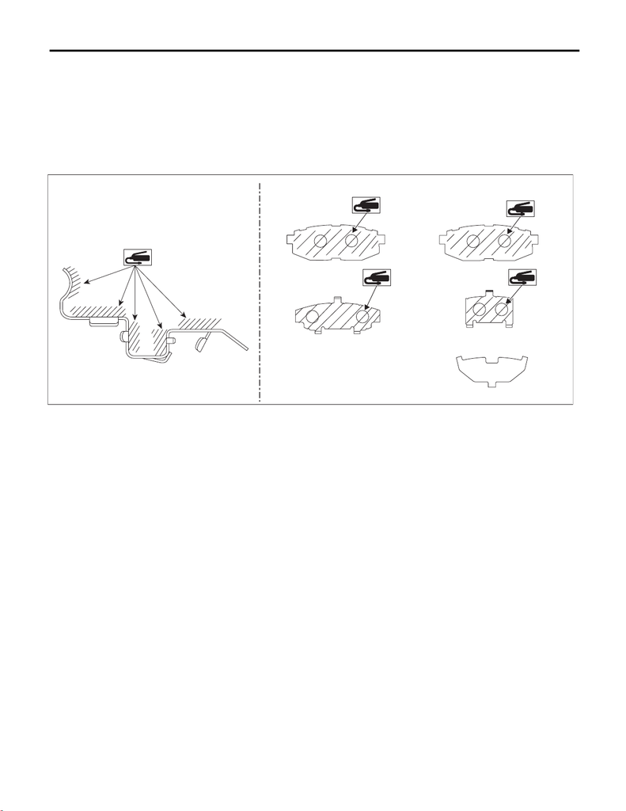

BR-45

Rear Disc Brake Assembly

BRAKE

3) Install the support - rear disc brake to the housing assembly - rear axle.

Tightening torque:

66 N·m (6.7 kgf-m, 48.7 ft-lb)

4) Apply a thin coat of grease to the pad clip, both sides of the shim - disc brake rear inner and the shim

mounting surface of the pad - disc brake rear.

Grease:

Pad clip (A): An item contained in the pad kit or equivalent

Shim and pad (B): An item contained in the pad kit or Molykote AS880N

5) Install the pad - disc brake rear.

NOTE:

Install the pad indicator in proper direction.

6) Install the caliper body assembly.

Tightening torque:

27 N·m (2.8 kgf-m, 19.9 ft-lb)

7) Install the brake hose bracket.

Tightening torque:

33 N·m (3.4 kgf-m, 24.3 ft-lb)

8) Connect the brake hose using a new brake hose gasket.

Tightening torque:

26 N·m (2.7 kgf-m, 19.2 ft-lb)

9) Bleed air from the brake system. <Ref. to BR-67, BRAKE LINE, PROCEDURE, Air Bleeding.>

10) Install the rear wheels.

Tightening torque:

120 N·m (12.2 kgf-m, 88.5 ft-lb)

(A) Pad clip - rear brake (B) Remove the pad - disc brake rear

and the shim - disc brake rear.

(a) Pad - disc brake rear outer (c) Shim - disc brake rear inner (e) Shim - disc brake rear outer

(b) Pad - disc brake rear inner (d) Shim - disc brake rear inner

BR-01274

(A) (B)

(c)

(a)

(b)

(d)

(e)

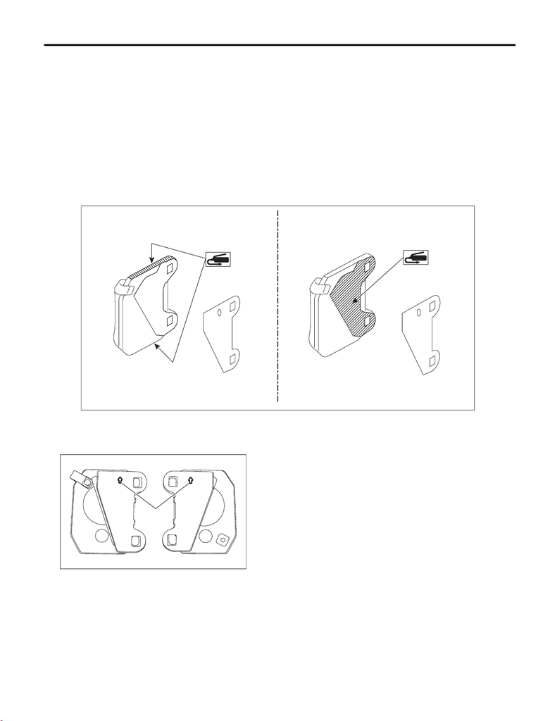

BR-46

Rear Disc Brake Assembly

BRAKE

2. STI MODEL

NOTE:

Before installation, remove mud and foreign matter from the disc brake assembly.

1) Check each part. <Ref. to BR-51, INSPECTION, Rear Disc Brake Assembly.>

2) Install the disc brake assembly.

Tightening torque:

66 N·m (6.7 kgf-m, 48.7 ft-lb)

3) Apply a thin coat of grease to the side of the pad - disc brake rear, both sides of the shim - disc brake rear

inner and the shim mounting surface of the pad - disc brake rear.

Grease:

Pad side (A): An item contained in the pad kit or equivalent

Shim and pad (B): An item contained in the pad kit or Molykote AS880N

4) Install the pad - disc brake rear.

NOTE:

Install so that the arrow (a) faces upward.

5) Install the cross spring.

6) Install the pin - disc brake.

7) Install the clip - slide pin.

8) Install the brake hose bracket.

Tightening torque:

33 N·m (3.4 kgf-m, 24.3 ft-lb)

BR-01275

(A) (B)

BR-01276

(a)

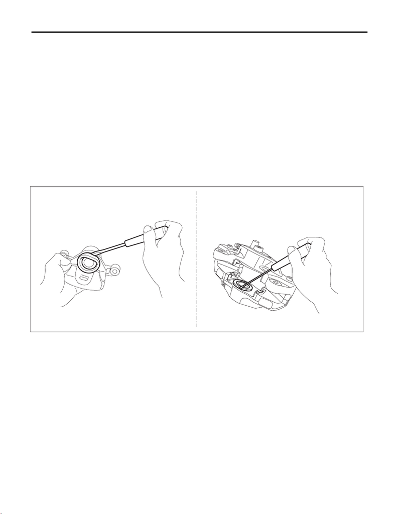

BR-47

Rear Disc Brake Assembly

BRAKE

9) Connect the brake hose using a new brake hose gasket.

Tightening torque:

26 N·m (2.7 kgf-m, 19.2 ft-lb)

10) Bleed air from the brake system. <Ref. to BR-67, BRAKE LINE, PROCEDURE, Air Bleeding.>

11) Install the rear wheels.

Tightening torque:

120 N·m (12.2 kgf-m, 88.5 ft-lb)

C: DISASSEMBLY

CAUTION:

• Be careful not to allow foreign matter to enter the brake hose connector.

• Since the 17-inch (Brembo) caliper body is easily scratched and the paint may be stripped, protect

it from being contacted with other parts or tools.

1) Remove mud and foreign matter from the caliper body assembly.

2) Remove the piston boot.

NOTE:

For STI model, remove the two piston boots.

(A) Except for STI model (B) STI model

BR-01285

(B)(A)

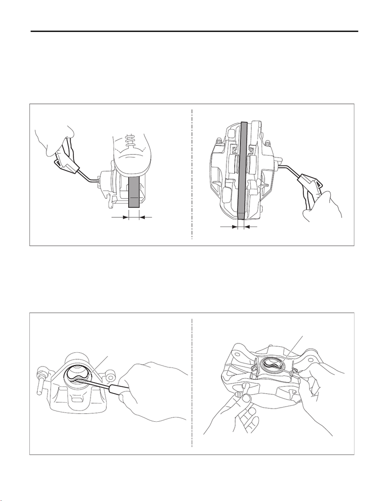

BR-48

Rear Disc Brake Assembly

BRAKE

3) Remove the piston - disc brake.

(1) Place a wooden block in the caliper body assembly as shown in the figure to prevent the piston - disc

brake from jumping out and being damaged.

(2) Using an air gun, gradually apply compressed air via the brake hose installation hole to push out the

piston - disc brake.

NOTE:

Instead of removing the pistons one by one, remove all pistons at once after adjusting the amount of protru-

sion evenly using a wooden block.

4) Remove the piston seal (a).

CAUTION:

Do not damage the piston sliding part and the piston seal groove.

NOTE:

(A) Except for STI model (B) STI model

(A) Except for STI model (B) STI model

BR-01286

(A) (B)

30 mm (1.18 in)

20 mm (0.79 in)

BR-01287

(B)(A)

(a)

(a)

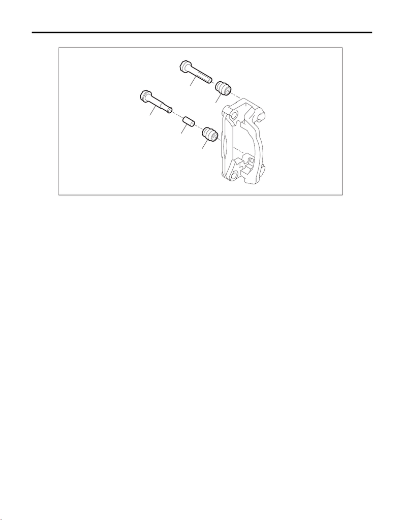

BR-49

Rear Disc Brake Assembly

BRAKE

5) Remove each part from support - rear disc brake. (Except for STI model)

(a) Guide pin - rear brake (black) (c) Lock pin - bushing (d) Pin boot

(b) Lock pin - rear brake (silver)

BR-00826

(c)

(d)

(d)

(b)

(a)

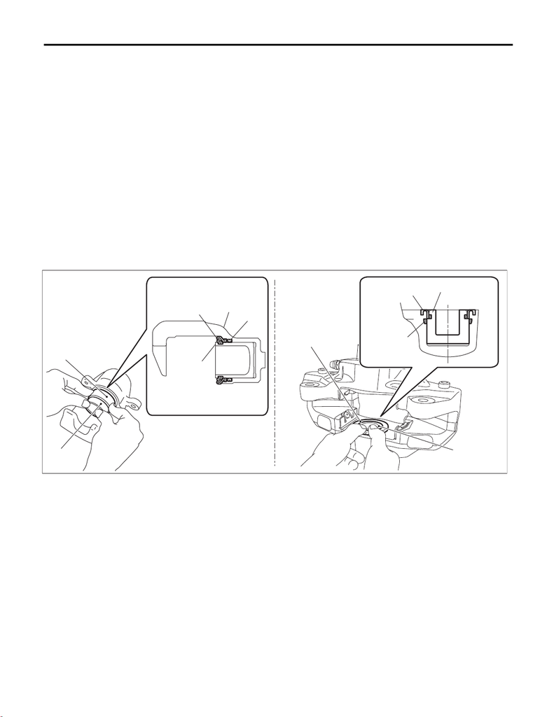

BR-50

Rear Disc Brake Assembly

BRAKE

D: ASSEMBLY

1) Check each part. <Ref. to BR-51, INSPECTION, Rear Disc Brake Assembly.>

2) Clean the inside of the caliper body using brake fluid.

Fluid:

FMVSS No. 116, DOT3 or DOT4

3) Install the piston seal and the piston - disc brake.

(1) Apply a coat of brake fluid to piston seal and install the piston seal to the groove inside caliper body.

(2) Apply a coat of brake fluid to the piston sliding part of caliper body and the entire outer surface of the

piston - disc brake.

Fluid:

FMVSS No. 116, DOT3 or DOT4

(3) Apply a coat of grease to the piston boot and fit to the groove on the ends of piston - disc brake.

Grease:

An item contained in the pad kit or Nippon Grease NIGLUBE RX-2

(4) Install the piston - disc brake to the caliper body.

CAUTION:

Do not force the piston - disc brake into the sliding part of caliper body.

4) Apply grease contained in the piston seal kit to the lock pin - rear brake, the outer surface of guide pin -

model)

(A) Except for STI model (B) STI model

(a) Piston - disc brake (c) Caliper body (d) Piston seal

(b) Piston boot

BR-01288

(a)

(b)

(a)

(b)

(c)

(d)

(a)

(B)(A)

(d)

(b)

(a)

(b)

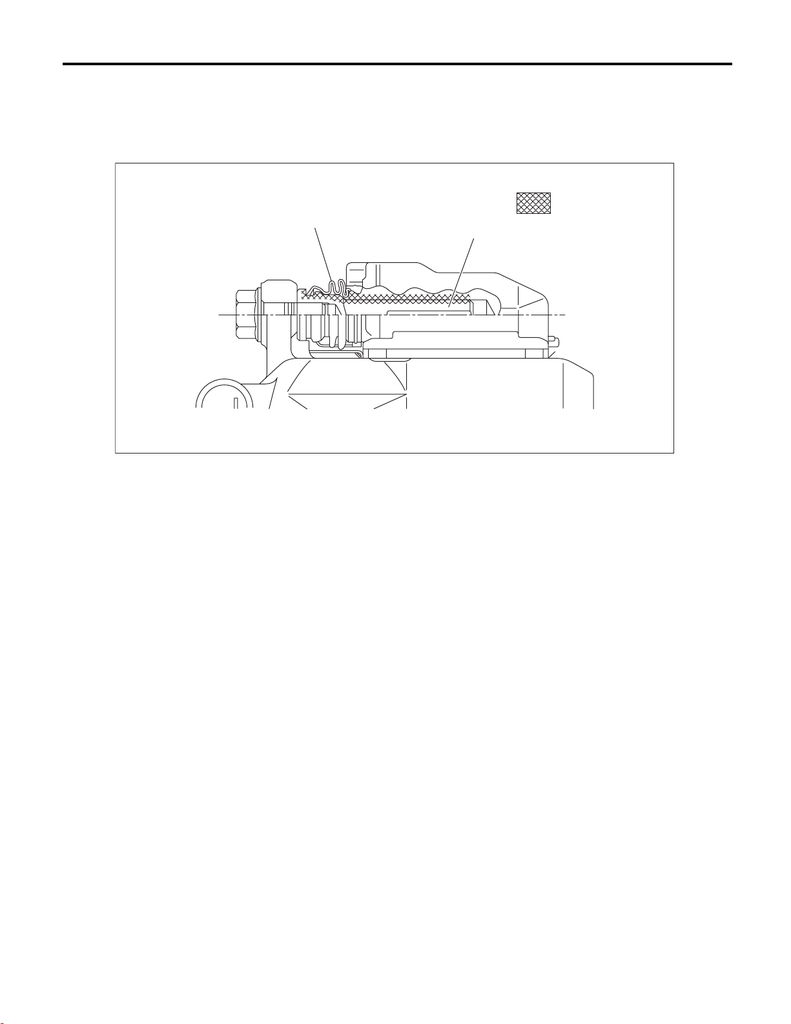

BR-51

Rear Disc Brake Assembly

BRAKE

5) Install the pin boot to the lock pin - rear brake and guide pin - rear brake, and insert them into the support - rear

disc brake.

CAUTION:

Insert the lock pin - rear brake and guide pin - rear brake into specified position, and make sure that

they slide and seat properly.

E: INSPECTION

1) Check the piston sliding part of caliper body and the piston - disc brake for uneven wear, damage or rust.

2) Check the rubber parts for damage or deterioration.

3) If faulty is found in the inspection, replace the relevant part.

(a) Pin boot (b) Lock pin - rear brake or guide pin -

rear brake

(c) Grease applied area

(a)

(b)

: (c)

BR-00930